# WEEK 1 CHALLENGE

Leonardo Schneider

# 📘 Predicting Book Prices – Challenge Week (R)

## 📌 Project Overview

This project is part of my **weekly data challenge** series, where I explore real-world datasets using R, Python, Excel, and Tableau. For this first week, I tackled the challenge “Predict Price of the Books” from MachineHack using **R**.

## 🎯 Objectives

- Clean and transform raw book data
- Visualize key patterns and relationships between features and price
- Build regression and Random Forest models to predict book prices
- Compare real vs. predicted prices visually
- Evaluate and interpret model performance
- Export predictions for unseen (test) data

# 📥 Data Import and Initial Setup

This section loads necessary packages and reads the training dataset for analysis.

```r
library(tidyverse)
library(readxl)
dados <- read_excel("C:/Users/leona/OneDrive/Área de Trabalho/WEEKLY CHALLENGE/Week1/Data_Test.xlsx")
dados2 <- read_excel("C:/Users/leona/OneDrive/Área de Trabalho/WEEKLY CHALLENGE/Week1/Data_Train.xlsx")


glimpse(dados)
```

```
## Rows: 1,560
## Columns: 8
## $ Title        <chr> "The Complete Sherlock Holmes: 2 Boxes sets", "Learn Dock…
## $ Author       <chr> "Sir Arthur Conan Doyle", "Gabriel N. Schenker", "Daniell…
## $ Edition      <chr> "Mass Market Paperback,– 1 Oct 1986", "Paperback,– Import…
## $ Reviews      <chr> "4.4 out of 5 stars", "5.0 out of 5 stars", "5.0 out of 5…
## $ Ratings      <chr> "960 customer reviews", "1 customer review", "4 customer …
## $ Synopsis     <chr> "A collection of entire body of work of the Sherlock Holm…
## $ Genre        <chr> "Short Stories (Books)", "Operating Systems Textbooks", "…
## $ BookCategory <chr> "Crime, Thriller & Mystery", "Computing, Internet & Digit…
```

```r
dados2 <- dados2 %>%
  mutate(Author_Clean = str_trim(str_split_fixed(Author, ",", 2)[,1]))
dados2 <- dados2 %>%
  mutate(Author_ID = as.numeric(as.factor(Author_Clean)))
```

# 🧹 Data Cleaning and Transformation

Here we clean and transform the dataset: parsing ratings, encoding categorical variables, and preparing the data for modeling.

```r
dados2 <- dados2 %>%
  mutate(
    Author_Clean = str_trim (str_split_fixed(Author, ",", 2)[,1]),
    Author_ID = as.numeric (as.factor(Author_Clean)),
    Edition_ID = as.numeric (as.factor(Edition)),
    Genre_ID = as.numeric (as.factor(Genre)),
    Category_ID = as.numeric(as.factor(BookCategory))
  )
```

# 📊 Exploratory Data Analysis (EDA)

We visualize key insights including genre distribution, price vs. rating correlation, top prices, and most frequent authors.

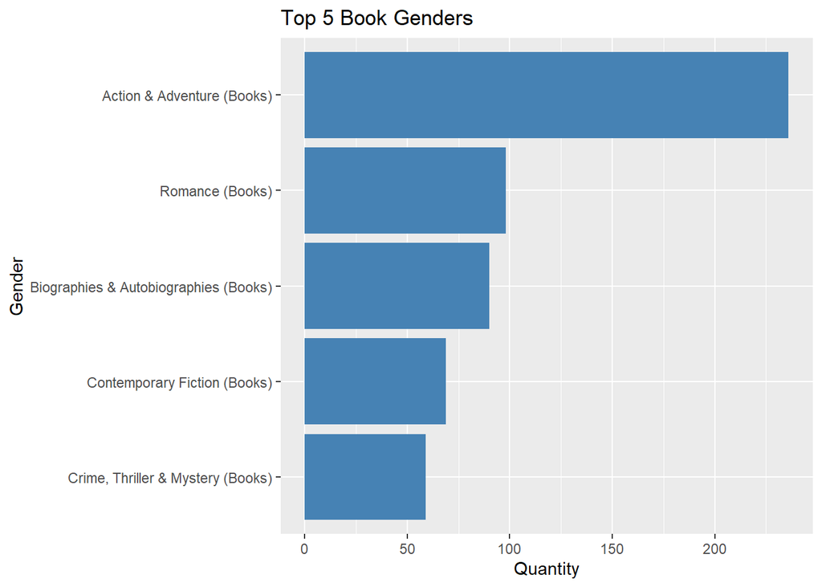

```r
library(dplyr)
library(ggplot2)

dados %>%
  count(Genre, sort = TRUE) %>%
  top_n(5) %>%
  ggplot(aes(x = reorder(Genre, n), y = n)) +
  geom_col(fill = "steelblue") +
  coord_flip() +
  labs(title = "Top 5 Book Genders", x = "Gender", y = "Quantity")
```

```r
dados2 %>%
  arrange(desc(Price)) %>%
  select(Title, Author, Price) %>%
  head(5)
```

```
## # A tibble: 5 × 3
##   Title                                                            Author  Price
##   <chr>                                                            <chr>   <dbl>
## 1 The Complete Asterix Box Set (36 Titles)                         Rene … 14100
## 2 Modern Labor Economics: Theory and Public Policy (The Addison-W… Ronal… 13245.
## 3 Fifty Cars that Changed the World: Design Museum Fifty           Desig… 11715.
## 4 On the Night of the Seventh Moon: The Classic Novel of Romantic… Victo…  9984
## 5 Ranga Roopa: Gods. Words. Images                                 B.N. …  9096
```

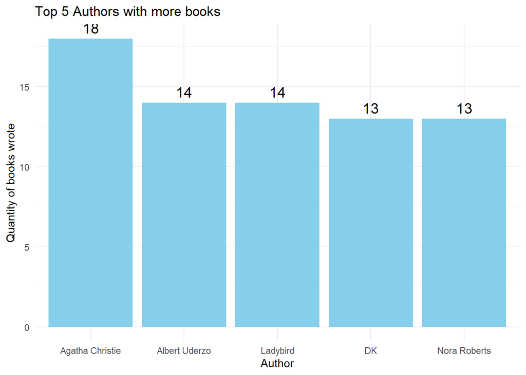

```r
library(ggplot2)
library(dplyr)

dados %>%
  count(Author, sort = TRUE) %>%
  top_n(5) %>%
  ggplot(aes(x = reorder(Author, -n), y = n)) +
  geom_col(fill = "skyblue") +
  geom_text(aes(label = n), vjust = -0.5, size = 5) +
  labs(title = "Top 5 Authors with more books", x = "Author", y = "Quantity of books wrote") +
  theme_minimal()
```

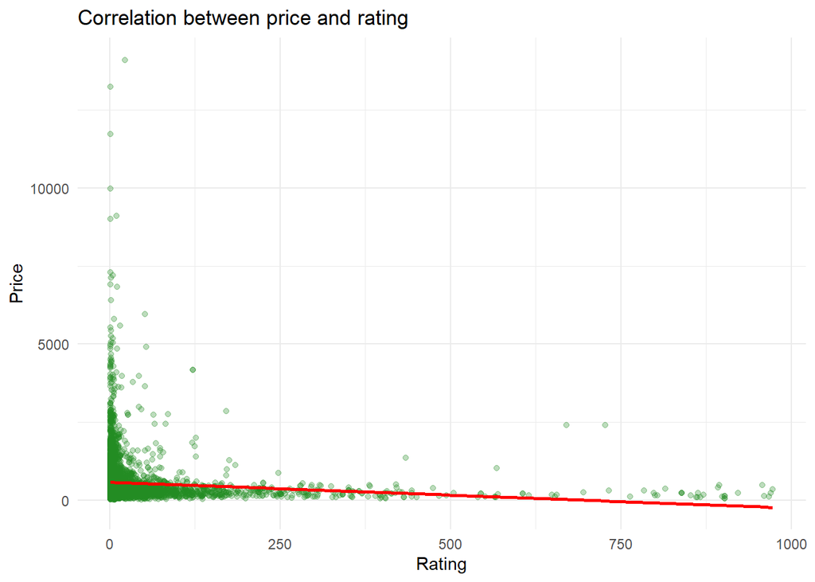

```r
dados2 <- dados2 %>%
  mutate(Rating_Num = as.numeric(str_extract(Ratings, "\\d+(\\.\\d+)?")))
dados2 <- dados2 %>%
  mutate(Rating_Group = cut(Rating_Num, breaks = c(0, 2, 3, 4, 5), labels = c("0–2", "2–3", "3–4", "4–5")))

ggplot(dados2, aes(x = Rating_Num, y = Price)) +
  geom_point(alpha = 0.3, color = "forestgreen") +
  geom_smooth(method = "lm", se = FALSE, color = "red", linewidth = 1) +
  theme_minimal() +
  labs(title = "Correlation between price and rating", x = "Rating", y = "Price")
```